# Paired Samples T-Tests with R

If participants answer the same question twice, say at time 1 and time 2, then we can test for differences in their responses with a paired samples t-test. This notebook will show you an easy way to conduct a paired-samples t-test in R.

First, let’s download the call PORL dataset.

```r
if (!require(foreign)){
  install.packages("foreign", dependencies = TRUE)
  require(foreign)
}
dataset = read.spss("https://osf.io/hwxre/download", to.data.frame=TRUE, use.value.labels = FALSE)
```

Two variables it might be interesting to test for differences between are attitudes toward Black men and Black women. It may be that Black men are evaluated more negatively than Black women becuase many of the negative stereotypes about Black people are focused on Black men in particular.

In R, we can conduct a paired samples t-test with a single line of code:

```r
t.test(dataset$MALES, dataset$FEMALES, paired = TRUE)
```

```
    Paired t-test

data:  dataset$MALES and dataset$FEMALES
t = -5.6904, df = 586, p-value = 2.004e-08
alternative hypothesis: true difference in means is not equal to 0
95 percent confidence interval:
 -3.687130 -1.794983
sample estimates:
mean of the differences
              -2.741056
```

In APA style we would write this as: *t*(586) = 5.69, *p* < .001.

We interpret this as:

A t-test was conducted. There were 586 degrees of freedom. The value of the t-test was 5.69. The p-value was less than .001. Therefore, assuming the null hypothesis is true, we would expect to see differences as or more extreme between these variables less than .001% of the time.

So there is a significant difference between the groups. But we don’t know which group was evaluated more positively. Let’s visualize the data to find out.

First, we will create a new data.frame() that only contains the two variables we’re interested in.

```r
myVariables <- data.frame(dataset$MALES,dataset$FEMALES)
colnames(myVariables) = c("Black men", "Black women")
head(myVariables)
```

|  | Black men | Black women |
| --- | --- | --- |
| 1 | 70 | 40 |
| 2 | 80 | 80 |
| 3 | 100 | 100 |
| 4 | 95 | 100 |
| 5 | 50 | 50 |
| 6 | 40 | 50 |

Next, we will ‘melt’ the myVariables data.frame() from ‘wide’ format to ‘long’ format.

```r
if (!require(reshape2)){
  install.packages("reshape2", dependencies = TRUE)
  require(reshape2)
}
myVariables.melt <- melt(myVariables)
colnames(myVariables.melt) = c("Gender", "Attitude")
tail(myVariables.melt)
```

|  | Gender | Attitude |
| --- | --- | --- |
| 1223 | Black women | 100 |
| 1224 | Black women | 80 |
| 1225 | Black women | 80 |
| 1226 | Black women | 85 |
| 1227 | Black women | 50 |
| 1228 | Black women | 100 |

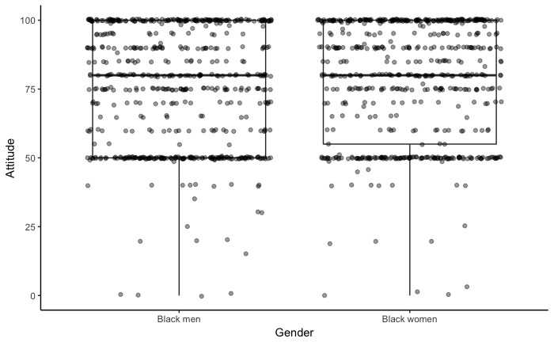

```r
if (!require(ggplot2)){
  install.packages("ggplot2", dependencies = TRUE)
  require(ggplot2)
}
ggplot(myVariables.melt, aes(x=Gender, y=Attitude)) + theme(panel.background = element_blank(), axis.line = element_line(color="black", size = .5)) + geom_boxplot() + geom_jitter(alpha = .4)
```

Clearly, the differences between these two groups is extremely small. It’s hard to even see it on this box plot!

Let’s just ask R to tell us the means.

```r
#Black men mean
mean(dataset$MALES, na.rm=TRUE)
```

```
[1] 75.49745
```

```r
#Black women mean
mean(dataset$FEMALES, na.rm=TRUE)
```

```
[1] 78.08784
```

So women are evaluated more positively, but the difference is very small.

We calculate the effect size to see just how small the difference is.

```r
if (!require(effsize)){
  install.packages("effsize", dependencies = TRUE)
  require(effsize)
}
tTestEffectSize = with(myVariables.melt, cohen.d(Attitude ~ Gender))
tTestEffectSize
```

```
Cohen's d

d estimate: -0.1216054 (negligible)
95 percent confidence interval:
        inf         sup
-0.23589367 -0.00731715
```

The cohen’s *d* = .12. this is smaller than small (Remember small is *d* = .2). R tell us that it is negligible.

We call also use the effSize package to calculate the hedge’s g. hedge’s g is useful when you have a small sample because it corrects the effect size estimate to take into account the size of the sample. Because we have a large sample, the hedge’s g and the cohen’s d should be very similar.

```r
if (!require(effsize)){
  install.packages("effsize", dependencies = TRUE)
  require(effsize)
}
tTestEffectSize2 = with(myVariables.melt, cohen.d(Attitude ~ Gender, hedges.correction = TRUE))
tTestEffectSize2
```

```
Hedges's g

g estimate: -0.121528 (negligible)
95 percent confidence interval:
        inf         sup
-0.23581617 -0.00723991
```

As you can see, the hedge’s g is also smaller than small (or negligible).

So we have a significant but neglibible difference between attitudes toward Black men and Black women.